# Variable Exploratory Analysis

Exploratory data analysis of the OST-R Project 16 database

- Connect to the database snapshot in the Volpe shared drive
- Re-create some of Mikio’s initial figures
- Make a slimmed-down version / specific tables for Tableau
- Save those in the shared drive

```r
source('../get_packages.R') # get all necessary packages

library(tidyverse)
```

```r
library(readr)
library(plotly)
data_location = '//vwfs05/3BC-SHARE$/OST-R Priority Projects/16. Contributing Factors to Trends in Roadway Fatalities/Data/CrashData'

# data_file = 'AcVeUPD.csv'
#
# d <- read_csv(file.path(data_location, data_file))

# Load from RData file, created previously from the csv. Much faster to load

load(file.path(data_location, 'AcVeUPD.RData'))
```

There are 668,219 rows and 294 columns of data.

TODO:

- Get final list of column names and meta-data from Mikio
- Create a reduced file for Tableau, with only key variables included

Notes from Mikio on the sample database:

> - This is a sample of the database we are creating (10,000 records for FARS, GES, CRSS)
> - The final database is >680,000 rows
> - The data contains 2 vehicles and relevant driver (these are named “variable”_1 or “variable”_2) "_nc" suffix denotes a variable that we tried to categorize based on its raw variable
> - This is a 1:1 of the raw data, case count wise. Not all variables are raw variables from the data, some are created by Volpe
> - This is created for our purposes and may not be the cleanest in its form, there are differences between N/A, null, “Missing”, Unknown, > Not Reported, Blank, etc…

> The things you need to start with: - SOURCE - WEIGHT - YEAR

> These 3 variables are the basis of the analysis, to identify trends over times in the variables. From here, its really plug and play.

> Happy to sit down and talk about anything (variable names, best next steps, etc…) My Task 1 Analysis are looking at these variables to refine our analysis, maybe we start in the same spot on how we show the data? ALCHL_IM, ALCOHOL, dr_dis’x’_nc, drimp’x’_nc, drvis’x’_nc, h_age, h_sex, highway_rc, TYP_INT,vtype

## Initial data exploration

```r
# Plot FARS and GES/CRSS cases in total by year
table(d$SOURCE)
```

```
##
##   CRSS   FARS    GES
## 149923 256631 261665
```

```r
# Counts by year by source. Create a new two-level source variable to combine GES (2011 to 2015) with CRSS (since 2016)
# sum over WEIGHT to get the crash counts. Row sums = case counts

counts_yr <- d %>%
  mutate(SOURCE2 = ifelse(SOURCE == 'FARS', 'FARS', 'GES/CRSS')) %>%
  group_by(SOURCE2, YEAR) %>%
  summarize(case_count = n(),
            crash_count = sum(WEIGHT))
```

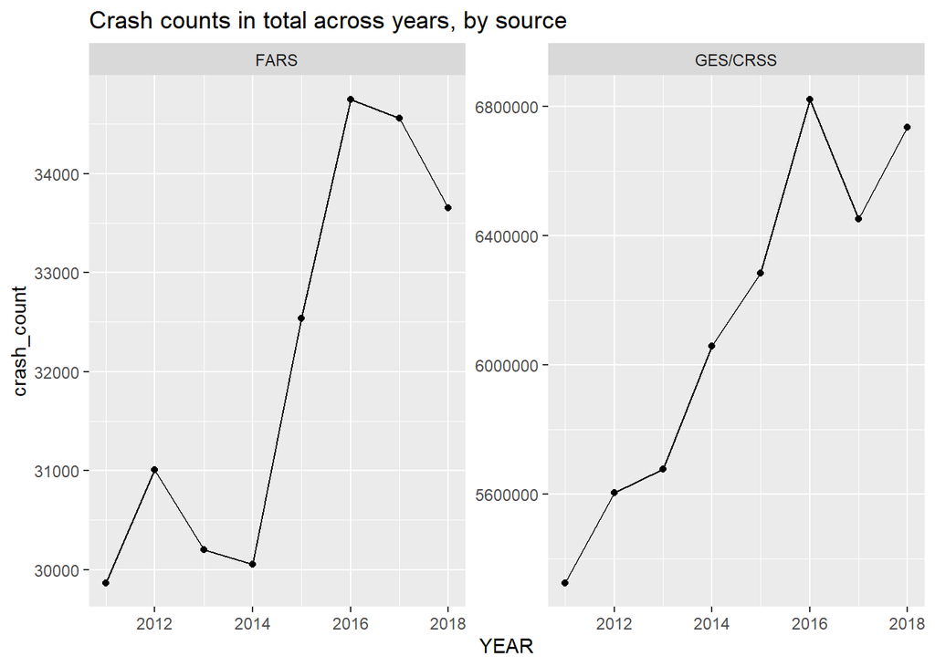

```r
ggplot(counts_yr, aes(x = YEAR, y = crash_count)) +
  geom_point() + geom_line() +
  facet_wrap(~SOURCE2, scales = 'free_y') +
  ggtitle('Crash counts in total across years, by source')
```

## Grouping plots

Aim to recreate slides 5 - 8

Validate against files in Teams folder Refer to the `Analysis` sheet

- Pre-crash scenario plots: `grouping`
- For FARS vs
- Body Type

```r
table(d$grouping, d$SOURCE) # number of rows. Need to sum WEIGHTs by these categories to get crash counts for GES/CRSS
```

```
##
##                             CRSS  FARS   GES
##   a. Vehicle Failure         875  2226  2540
##   b. Control Loss           9117 43266 28395
##   c. Road Departure        17576 66039 30706
##   d. Animal                 6032  1864  9030
##   e. Pedestrian             6980 39214 11414
##   f. Cyclist                4687  5499  7547
##   g. Lane Change           17215  8359 26012
##   h. Opp Direction          3418 28423  6175
##   i. Rear End              42339 16186 66014
##   j. Lateral Crossing Path 21671 25298 39005
##   k. LTAP/OD                9724 10930 18071
##   l. Other                 10288  9327 16756
```

```r
table(d$grouping, d$vtype_sv) # sv = subject-vehicle
```

```
##
##                               Bus Light vehicle Medium heavy Missing
##   a. Vehicle Failure           19          4273          790       5
##   b. Control Loss              57         67940         2575      90
##   c. Road Departure           373         95608         4831     126
##   d. Animal                    21         14878          399      11
##   e. Pedestrian               725         50339         2539       6
##   f. Cyclist                  206         16276          741       3
##   g. Lane Change              346         42477         6363      38
##   h. Opp Direction             80         34232         1418      30
##   i. Rear End                 311        112476         6673      41
##   j. Lateral Crossing Path    397         77686         4153      58
##   k. LTAP/OD                  167         36884         1190       7
##   l. Other                    323         25660         4367      82
##
##                            Motored cycle  Other Unknown
##   a. Vehicle Failure                 501     47       6
##   b. Control Loss                   9147    926      43
##   c. Road Departure                11894   1205     284
##   d. Animal                         1524     91       2
##   e. Pedestrian                      443     48    3508
##   f. Cyclist                         165     13     329
##   g. Lane Change                    1992    264     106
##   h. Opp Direction                  2055    161      40
##   i. Rear End                       4819     95     124
##   j. Lateral Crossing Path          3406    219      55
##   k. LTAP/OD                         378     64      35
##   l. Other                          5049    532     358
```

```r
table(d$vtype_sv, d$vtype_pv) # sv = subject-vehicle, pv = principal-other vehicle (the vehicle being struck)
```

```
##
##                    Bus Light vehicle Medium heavy Missing Motored cycle  Other
##   Bus               47          1447          133    1274           118      3
##   Light vehicle   2437        293129        26209  238946         16854    899
##   Medium heavy     173         19524         2909   12463           854     88
##   Missing            0           169            8     312             3      4
##   Motored cycle     64         10609          935   28775           839     73
##   Other              4           662           68    2752            78     98
##   Unknown            2           226           13    4425           155      4
##
##                 Unknown
##   Bus                 3
##   Light vehicle     256
##   Medium heavy       28
##   Missing             1
##   Motored cycle      78
##   Other               3
##   Unknown            65
```

```r
# Getting towards the Danish plots
# table(d$grouping, d$vtype_sv, d$vtype_pv) # sv = subject-vehicle, pv = principal-other vehicle (the vehicle being struck)

table(d$grouping, d$SOURCE)
```

```
##
##                             CRSS  FARS   GES
##   a. Vehicle Failure         875  2226  2540
##   b. Control Loss           9117 43266 28395
##   c. Road Departure        17576 66039 30706
##   d. Animal                 6032  1864  9030
##   e. Pedestrian             6980 39214 11414
##   f. Cyclist                4687  5499  7547
##   g. Lane Change           17215  8359 26012
##   h. Opp Direction          3418 28423  6175
##   i. Rear End              42339 16186 66014
##   j. Lateral Crossing Path 21671 25298 39005
##   k. LTAP/OD                9724 10930 18071
##   l. Other                 10288  9327 16756
```

### Slide 7: Proportion of crashes groups, over years

For FARS

```r
fars_total_yr <- d %>%
  filter(SOURCE == 'FARS') %>%
  ungroup() %>%
  group_by(YEAR) %>%
  summarize(sum_crashes_tot = sum(WEIGHT))
fars_grouping_yr <- d %>%
  filter(SOURCE == 'FARS') %>%
  ungroup() %>%
  group_by(YEAR, grouping) %>%
  summarize(sum_crashes_grp = sum(WEIGHT))
fars_grouping <- full_join(fars_total_yr, fars_grouping_yr)
fars_grouping_prop <- fars_grouping %>%
  ungroup() %>%
  group_by(YEAR, grouping) %>%
  summarize(prop_crashes_group = round(100 * sum_crashes_grp / sum_crashes_tot, 2))
```

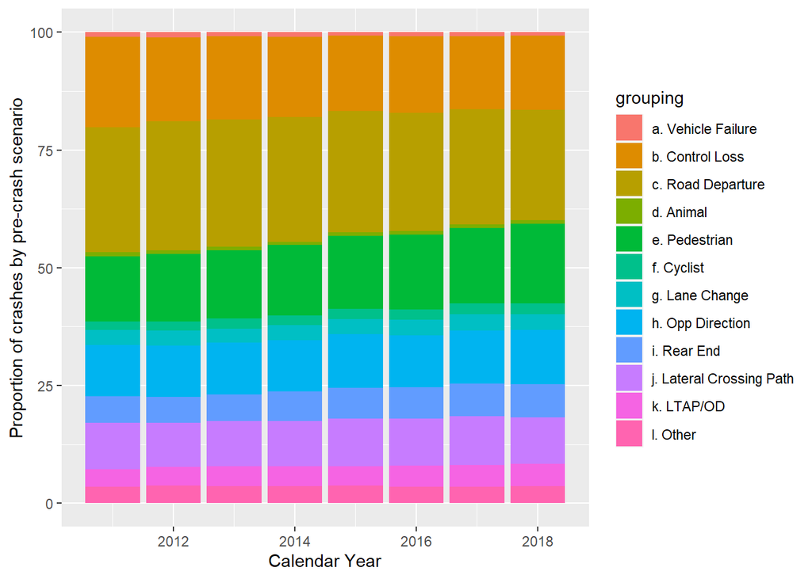

```r
slide7 <- ggplot(fars_grouping_prop, aes(x = YEAR, y = prop_crashes_group,
                               fill = grouping)) +
  geom_bar(position = 'stack', stat = 'identity') +
  ylab('Proportion of crashes by pre-crash scenario') +
  xlab('Calendar Year')

slide7
```

```r
# and adding an interactive version

ggplotly(slide7)
```

[interactive chart not shown]